# Project: Investigate a Dataset - TMDb Movie Data

- Introduction
- Data Wrangling
- Loading the dataset
- Assesing the Dataset
- Data Cleaning
- Exploratory Data Analysis
- Question 1: How do genre trends and their revenue contributions evolve over time?
- Question 2: How do the most frequent actors influence average movie ratings over time?
- Conclusions

## 1.0 Introduction

### Dataset Description

The TMDb dataset contains information on 10,000 movies, including user ratings, revenue, genres, and cast details. For this project, we aim to explore the following questions:

### Question for Analysis

1. How do genre trends and their revenue evolve over time?
2. How do the most frequent actors influence average movie ratings over time?

Let's began with importing necessary libraries.

## 2.0 Data Wrangling

### Gather

Next, loading the TMDb_movie dataset for Data Wrangling and initial exploration. Let's look for that Movies dataset.

```python
# Import libraries
import pandas as pd
import numpy as np
import matplotlib.pyplot as plt #plotting
import seaborn as sns #Plot style
```

## Load the Dataset

```python
# List all CSV files
import os
datasets = [file for file in os.listdir() if file.endswith('.csv')]
print(datasets)
```

```
[]
```

Nothing there, checking subdirectories.

```python
# List all CSV files in subdirectories
import glob
datasets = glob.glob('**/*.csv', recursive=True)
print(datasets)
```

```
['Database_Ncis_and_Census_data/US_Census_Data.csv', 'Database_Ncis_and_Census_data/gun_data.csv', 'Database_TMDb_movie_data/tmdb-movies.csv', 'Database_No_show_appointments/noshowappointments-kagglev2-may-2016.csv']
```

There it is! 'Database_TMDb_movie_data/tmdb-movies.csv'

```python
# Load the datasets
data_path_movies = 'Database_TMDb_movie_data/tmdb-movies.csv'
movies_df = pd.read_csv('Database_TMDb_movie_data/tmdb-movies.csv')
```

## Assessing the Data

```python
# number of rows, columns in the dataset
movies_df.shape
```

```
(10866, 21)
```

```python
# Function to display multiple values
# Check for null values, duplicates, and data types to understand what cleaning is needed.
#  Assess a DataFrame by displaying:
#  - The total number of rows
#  - Column summary (non-null count, percentage, and data type)
#  - Duplicate value percentages for each column

def assess_dataframe(df):
    total_rows = len(df)

    # Column Summary
    print("Column Summary:")
    column_info = []
    for i, column in enumerate(df.columns):  # Include column index
        non_null_count = df[column].notnull().sum()
        non_null_percentage = (non_null_count / total_rows) * 100
        data_type = df[column].dtype
        column_info.append([i, column, non_null_count, f"{non_null_percentage:.1f}%",data_type])

    # Create DataFrame with only necessary columns
    col_summary = pd.DataFrame(column_info, columns=["Column #", "Column", "Non-null Count", "Non-null %", "Data Type"])
    col_summary = col_summary.sort_values(by="Column #")  # Sort by column index

    print(col_summary.to_string(index=False))

    # Duplicate Summary
    print("\nDuplicate Summary:")
    duplicate_counts = df.nunique()
    duplicate_percentage = (1 - (duplicate_counts / total_rows)) * 100

    # Create duplicate summary DataFrame with column index
    duplicate_summary = pd.DataFrame({
        "Column #": range(len(df.columns)),  # Preserve column order
        "Column": df.columns,  # Include Column Name
        "Unique Values": duplicate_counts.values,  # Fixed syntax
        "Duplicate Percentage": [f"{x:.1f}%" for x in duplicate_percentage.values]  # Format with percent sign
    })

    duplicate_summary = duplicate_summary.sort_values(by="Column #")  # Ensure sorting by original order
    print(duplicate_summary.to_string(index=False)) # Print without Pandas index

    # Addtional one-line insights
    print(f"\nAddtional insights:")
    print(f"DataFrame contains {total_rows} rows.")

    duplicate_ids = movies_df['id'].duplicated().sum()
    print(f"Number of duplicate IDs: {duplicate_ids}")

    total_duplicates = movies_df.duplicated().sum()
    print(f"Total number of fully duplicated rows: {total_duplicates}")
```

```python
assess_dataframe(movies_df)
```

```
Column Summary:
 Column #               Column  Non-null Count Non-null % Data Type
        0                   id           10866     100.0%     int64
        1              imdb_id           10856      99.9%    object
        2           popularity           10866     100.0%   float64
        3               budget           10866     100.0%     int64
        4              revenue           10866     100.0%     int64
        5       original_title           10866     100.0%    object
        6                 cast           10790      99.3%    object
        7             homepage            2936      27.0%    object
        8             director           10822      99.6%    object
        9              tagline            8042      74.0%    object
       10             keywords            9373      86.3%    object
       11             overview           10862     100.0%    object
       12              runtime           10866     100.0%     int64
```

[output cut: 37 more lines]

General Overview:

- The dataset consists of 10,866 rows and 21 columns.
- There is 1 duplicate ID and 1 fully duplicated row in the dataset.

Data Completeness:

- Most essential columns (e.g., id, popularity, budget, revenue, original_title, release_date) are fully populated. Homepage and tagline have the most missing values.

Duplicate Data Issues:

- The `id` column has 1 duplicate, indicating a potential data entry issue.
- High duplication rates in `budget` (94.9%), `vote_average` (99.3%), and `release_year` (99.5%) suggest many movies share the same values, possibly due to missing distinct information or rounding.

Financial Data Trends:

- `budget` and `revenue` have a high duplication rate, indicating many movies share identical values or zeros.
- The `budget_adj` and `revenue_adj` columns provide inflation-adjusted values, which might be more useful for further analysis.

Text-Based Data:

- `original_title`, `overview`, and `cast` have high uniqueness, suggesting a strong variety in movie content.
- `tagline` and `keywords` show a notable percentage of duplication, which could mean many movies use similar phrases.

Data Observations: The dataset covers 56 unique years, meaning the movies span multiple decades.

- `release_date` has 45.6% duplicates, which indicates that many movies share the same release dates.

### Data Cleaning

Next steps for analysis, some Format Adjustments on `release_date`, investigate and remove the any fully duplicated rows. For missing values, inputing values or dropping columns with high missing percentages.

```python
# Correct format and correct dates on future dates
# Convert release_date to datetime, specifying the correct format
movies_df['release_date'] = pd.to_datetime(movies_df['release_date'], format='%m/%d/%y', errors='coerce')

# Looks like we have an issue with dates after changing the `release_date` column type.
# Fix incorrect future dates (e.g., 2072 should be 1972)
movies_df.loc[movies_df['release_date'] > pd.to_datetime('12/31/2023'), 'release_date'] -= pd.DateOffset(years=100)

# Verify corrections
suspicious_dates = movies_df[(movies_df['release_date'] > '12/31/2023') | (movies_df['release_date'] < '01/01/1900')]
print(f"Remaining suspicious dates: {len(suspicious_dates)}")
print(suspicious_dates[['original_title', 'release_date']])
```

```
Remaining suspicious dates: 0
Empty DataFrame
Columns: [original_title, release_date]
Index: []
```

Convert `release_date` to datetime, the `release_date` column is essential for time-based analysis such as trends over years and decades. Now we can easily extract year and decade information for grouping and visualization.

However, doing this created and issue with "19--" dates, so we offset those dates 100 years.

Moving on, count the number of duplicate entries to understand the scale of any issues.

```python
# Check for Duplicates
duplicate_ids = movies_df[movies_df.duplicated(subset=['id'], keep=False)]
print(duplicate_ids.sort_values(by='id').head(10))  # Show first 10 duplicate rows

duplicate_count = movies_df.duplicated(subset=['id']).sum()
print(f"Number of duplicate IDs: {duplicate_count}")# Count duplicate IDs
```

```
         id    imdb_id  popularity    budget  revenue original_title  \
2089  42194  tt0411951           1  30000000   967000         TEKKEN
2090  42194  tt0411951           1  30000000   967000         TEKKEN

                                                   cast homepage  \
2089  Jon Foo|Kelly Overton|Cary-Hiroyuki Tagawa|Ian...      NaN
2090  Jon Foo|Kelly Overton|Cary-Hiroyuki Tagawa|Ian...      NaN

              director              tagline  ...  \
2089  Dwight H. Little  Survival is no game  ...
2090  Dwight H. Little  Survival is no game  ...

                                               overview runtime  \
2089  In the year of 2039, after World Wars destroy ...      92
2090  In the year of 2039, after World Wars destroy ...      92

                                           genres    production_companies  \
2089  Crime|Drama|Action|Thriller|Science Fiction  Namco|Light Song Films
2090  Crime|Drama|Action|Thriller|Science Fiction  Namco|Light Song Films

     release_date vote_count  vote_average  release_year  budget_adj  \
2089   2010-03-20        110             5          2010  30,000,000
2090   2010-03-20        110             5          2010  30,000,000

      revenue_adj
2089      967,000
2090      967,000

[2 rows x 21 columns]
Number of duplicate IDs: 1
```

```python
movies_df = movies_df.drop_duplicates(subset=['id'], keep='first')
```

Find and remove fully duplicated rows, duplicate entries in the dataset can distort analysis by overrepresenting certain movies. Removing duplicates ensures that each movie is represented only once, maintaining the integrity of the dataset.

Drop non-critical columns

- `homepage`: Contains URLs to movie websites, which are not useful for our quantitative analysis.
- `tagline`: While interesting, taglines are not critical for exploring trends in movies.
- `keywords`: Contains specific terms or themes but requires extensive preprocessing and may not directly support our questions.
- `overview`: Provides a text summary of the movie but is not relevant for numerical or trend analysis.
- `popularity` : Provides a rating of the movie but is not relevant for this analysis.
- `runtime` : Provides a length of the movie but is not relevant for this analysis. Dropping these columns helps streamline the dataset and focus on key variables.

```python
noncritical_columns_to_drop = ['homepage', 'tagline', 'keywords', 'overview', 'popularity', 'runtime', 'production_companies',]

# Drop only if they exist in the dataset to avoid errors
movies_df = movies_df.drop(columns=[col for col in noncritical_columns_to_drop if col in movies_df.columns], axis=1)

# Verify the columns were removed
assess_dataframe(movies_df)
```

```
Column Summary:
 Column #         Column  Non-null Count Non-null %      Data Type
        0             id           10865     100.0%          int64
        1        imdb_id           10855      99.9%         object
        2         budget           10865     100.0%          int64
        3        revenue           10865     100.0%          int64
        4 original_title           10865     100.0%         object
        5           cast           10789      99.3%         object
        6       director           10821      99.6%         object
        7         genres           10842      99.8%         object
        8   release_date           10865     100.0% datetime64[ns]
        9     vote_count           10865     100.0%          int64
       10   vote_average           10865     100.0%        float64
       11   release_year           10865     100.0%          int64
       12     budget_adj           10865     100.0%        float64
```

[output cut: 23 more lines]

```python
# Handle missing values in director,cast and genres
print(f"Director updates: {movies_df['director'].isna().sum()}")
movies_df['director'].fillna('Unknown', inplace=True)

print(f"Cast updates: {movies_df['cast'].isna().sum()}")
movies_df['cast'].fillna('No Cast Info', inplace=True)

print(f"Genre updates: {movies_df['genres'].isna().sum()}")
movies_df['genres'].fillna('No Genre Info', inplace=True)
```

```
Director updates: 44
Cast updates: 76
Genre updates: 23
```

Handle missing values in `director`,`cast`, `genres`.

The `director`, `cast` and `genres` columns are important for our analysis as they contribute to understanding the impact of directors and cast members on movie revenue.

```python
# Remove rows with missing critical values
movies_df = movies_df.dropna(subset=['budget', 'revenue'])
```

Remove rows with missing critical values

The `budget`, and `revenue` columns are essential for answering our research questions.

- Missing `budget` or `revenue` values would compromise calculations and comparisons of financial trends.

Dropping rows with missing values in these columns ensures our analysis remains accurate and meaningful.

Next, lets format and update addtional column datatypes.

```python
# Formatting to display numbers with commas and two decimal places.
# Set global float format for better readability
pd.options.display.float_format = '{:,.0f}'.format
```

```python
# Display a snapshot of the cleaned data after removing duplicates
assess_dataframe(movies_df)
```

```
Column Summary:
 Column #         Column  Non-null Count Non-null %      Data Type
        0             id           10865     100.0%          int64
        1        imdb_id           10855      99.9%         object
        2         budget           10865     100.0%          int64
        3        revenue           10865     100.0%          int64
        4 original_title           10865     100.0%         object
        5           cast           10865     100.0%         object
        6       director           10865     100.0%         object
        7         genres           10865     100.0%         object
        8   release_date           10865     100.0% datetime64[ns]
        9     vote_count           10865     100.0%          int64
       10   vote_average           10865     100.0%        float64
       11   release_year           10865     100.0%          int64
       12     budget_adj           10865     100.0%        float64
```

[output cut: 23 more lines]

Key Column-Specific Analysis

Dropped Columns: Not necessary for this analysis, though some will be very useful for further analysis.

```python
# Finalizing the clean dataset, after all data cleaning steps
clean_movies_df = movies_df.copy()
```

Rename the dataset to indicate it's ready for analysis.

# 3.0 Exploratory Data Analysis

### Question 1

How do genre trends and their revenue contributions evolve over time?

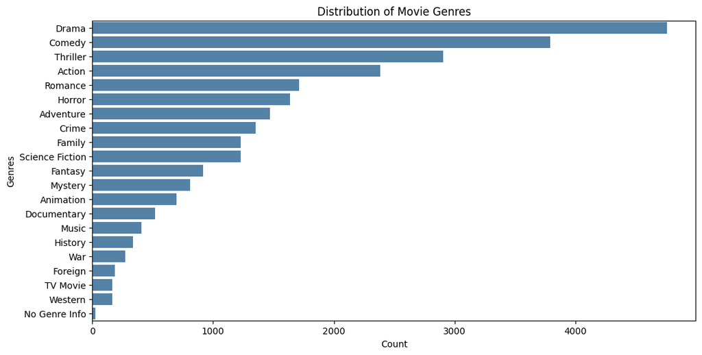

```python
# Question 1, 1DPlot
# Define columns to visualize
columns_to_plot = [ 'genres']

# Set figure size
plt.figure(figsize=(12, 6))

# Split and Transform the `genres` Column
clean_movies_df['genres'] = clean_movies_df['genres'].str.split('|')
clean_movies_df = clean_movies_df.explode('genres')


# Count plot for categorical variable 'genres'
sns.countplot(y=clean_movies_df['genres'], order=clean_movies_df['genres'].value_counts().index, color='steelblue')

# Improve readability
plt.title('Distribution of Movie Genres')
plt.xlabel('Count')
plt.ylabel('Genres')
plt.grid(False)

plt.show()
```

A quick look at the distribution of Movie Genres, Drama and Comedy dominating in the dataset.

```python
# Question 1: Genres Over Time - How do genre trends and their revenue contributions evolve over time?

# Split and Transform the `genres` Column
clean_movies_df['genres'] = clean_movies_df['genres'].str.split('|')
clean_movies_df = clean_movies_df.explode('genres')

# Group by Year and Genre
clean_movies_df['release_year'] = clean_movies_df['release_date'].dt.year

genre_trends = clean_movies_df.groupby(['release_year', 'genres']).size().reset_index(name='count')
genre_revenue = clean_movies_df.groupby(['release_year', 'genres'])['revenue'].sum().reset_index()

# Filter for Top 10 Genres by Total Coun
top_15_genres = genre_trends.groupby('genres', as_index=False)['count'].sum().nlargest(10, 'count')['genres']
filtered_genre_trends = genre_trends[genre_trends['genres'].isin(top_15_genres)]
filtered_genre_revenue = genre_revenue[genre_revenue['genres'].isin(top_15_genres)]
```

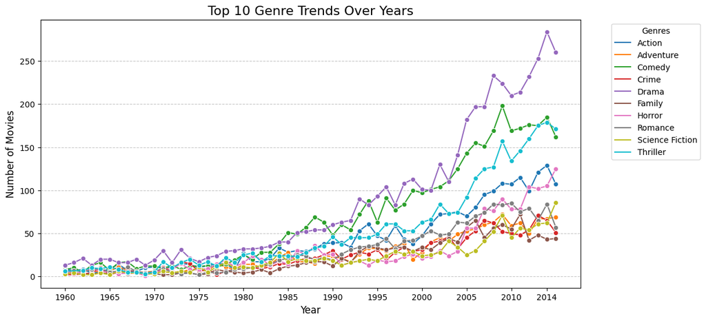

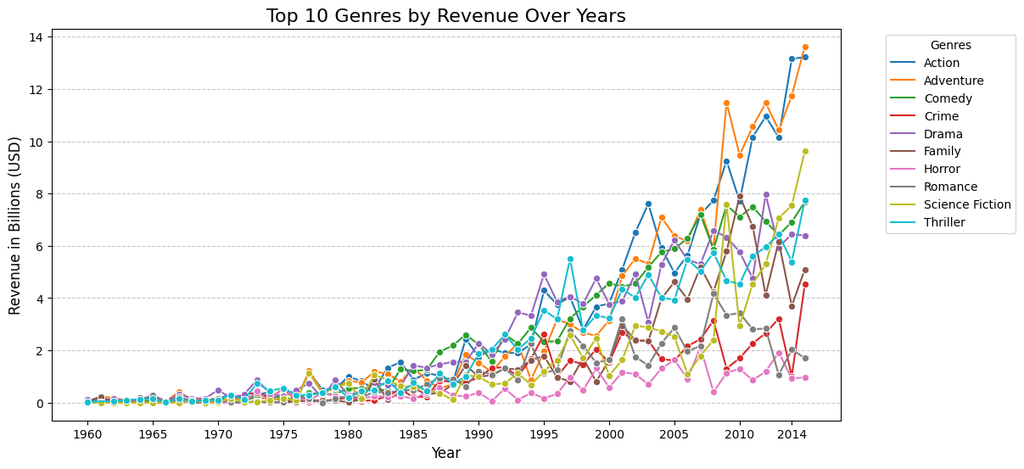

```python
# Visualization of Trends
# 2DPlot: Genre Trends for Top 10 Genres
plt.figure(figsize=(12, 6))
sns.lineplot(data=filtered_genre_trends, x='release_year', y='count', hue='genres', marker='o')
plt.title('Top 10 Genre Trends Over Years', fontsize=16)
plt.xlabel('Year', fontsize=12)
plt.ylabel('Number of Movies', fontsize=12)
plt.xticks(list(range(1960, 2015, 5)) + [2014])  # Set x-axis ticks every 5 years and include 2014
plt.grid(axis='y', linestyle='--', alpha=0.7)
plt.legend(title='Genres', bbox_to_anchor=(1.05, 1), loc='upper left')
plt.show()

# 2DPlot: Revenue Trends for Top 10 Genres
plt.figure(figsize=(12, 6))
sns.lineplot(data=filtered_genre_revenue.assign(revenue=filtered_genre_revenue['revenue'] / 1e9), x='release_year', y='revenue', hue='genres', marker='o')
plt.title('Top 10 Genres by Revenue Over Years', fontsize=16)
plt.xlabel('Year', fontsize=12)
plt.ylabel('Revenue in Billions (USD)', fontsize=12)
plt.xticks(list(range(1960, 2015, 5)) + [2014])  # Set x-axis ticks every 5 years and include 2014
plt.grid(axis='y', linestyle='--', alpha=0.7)
plt.legend(title='Genres', bbox_to_anchor=(1.05, 1), loc='upper left')
plt.show()
```

Key Observations

Top 10 Genre Trends Over Years

From the 1960s to the 1980s, the number of movies produced in each genre remained relatively steady and low, with no genre showing significant dominance.

Starting in the 1990s, there was a significant increase in the number of movies across most genres, with some genres like Drama, Action, and Comedy showing a particularly sharp rise.

Top 10 Genres by Revenue Over Years

From the 1960s to the 1980s: Revenue growth remained modest across all genres, with no major spikes.

Comedy and Family movies also maintained steady revenue growth, driven by animated features and major studio investments. Drama, despite being the most frequently produced genre, lags in revenue compared to high-budget blockbusters.

### Question 2

How do the most frequent actors influence average movie ratings over time?

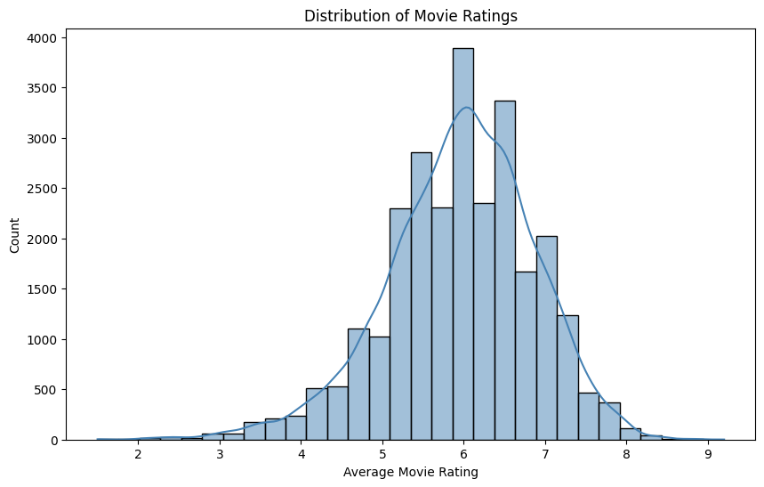

```python
# Question 1, 1DPlot
# Set figure size
plt.figure(figsize=(10, 6))

# Create a histogram of average movie ratings
sns.histplot(clean_movies_df['vote_average'], bins=30, kde=True, color='steelblue')

# Improve readability
plt.title('Distribution of Movie Ratings')
plt.xlabel('Average Movie Rating')
plt.ylabel('Count')
plt.grid(False)

plt.show()
```

A quick look at the Distribution of Average Movie Ratings, looks like 6 is a strong average throughout the dataset.

```python
# Identify the Most Frequent Actors (Top 25)
actor_list = []
for cast in clean_movies_df['cast'].dropna():
    actor_list.extend(cast.split('|'))

# Count occurrences manually
actor_counts = {}
for actor in actor_list:
    if actor in actor_counts:
        actor_counts[actor] += 1
    else:
        actor_counts[actor] = 1

# Convert to DataFrame
actor_counts_df = pd.DataFrame(list(actor_counts.items()), columns=['Actor', 'Appearance Count'])

# Get Top 25 Most Frequent Actors
top_actors = actor_counts_df.sort_values(by='Appearance Count', ascending=False).head(10)
top_actor_names = top_actors['Actor'].tolist()
```

```python
# Extract Decades from Release Year
clean_movies_df['release_year'] = pd.to_datetime(clean_movies_df['release_date'], errors='coerce').dt.year
clean_movies_df['decade'] = (clean_movies_df['release_year'] // 10) * 10
```

```python
# Compare Average Movie Ratings for Each Actor by Decade
actor_decade_ratings = []

for actor in top_actor_names:
    actor_movies = clean_movies_df[clean_movies_df['cast'].str.contains(actor, na=False)]
    actor_decade_avg = actor_movies.groupby('decade')['vote_average'].mean().reset_index()#Find the Average Movie Rating
    actor_decade_avg['Actor'] = actor  # Add actor name to dataset
    actor_decade_ratings.append(actor_decade_avg)

# Convert to DataFrame
actor_decade_ratings_df = pd.concat(actor_decade_ratings)

# Display results
print(actor_decade_ratings_df.head(10))  # Show a sample of the data
```

```
   decade  vote_average              Actor
0    1990             6  Samuel L. Jackson
1    2000             6  Samuel L. Jackson
2    2010             6  Samuel L. Jackson
0    1980             6       Bruce Willis
1    1990             6       Bruce Willis
2    2000             6       Bruce Willis
3    2010             6       Bruce Willis
0    1980             6       Nicolas Cage
1    1990             6       Nicolas Cage
2    2000             6       Nicolas Cage
```

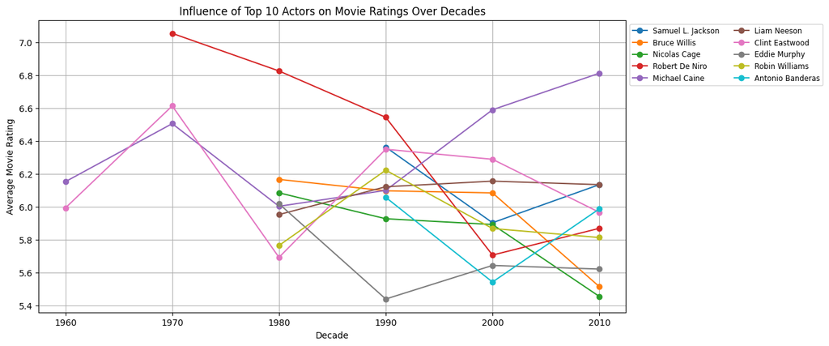

```python
# Visualize Actor Influence Over Decades
plt.figure(figsize=(12, 6))
for actor in top_actor_names:
    subset = actor_decade_ratings_df[actor_decade_ratings_df['Actor'] == actor]
    plt.plot(subset['decade'], subset['vote_average'], marker='o', linestyle='-', label=actor)

plt.xlabel("Decade")
plt.ylabel("Average Movie Rating")
plt.title("Influence of Top 10 Actors on Movie Ratings Over Decades")
plt.legend(loc='upper left', bbox_to_anchor=(1, 1), fontsize='small', ncol=2)
plt.grid(True)
plt.show()
```

This chart reveals how the average ratings of movies starring major actors evolved over time. Some careers saw legendary peaks and declines, while others maintained remarkable consistency.

Standout Trends & Stories:

Michael Caine – A Career Reinvented

- Started modestly but saw a huge resurgence in the 2000s-2010s, fueled by Nolan’s Batman Trilogy & Inception.
- One of the few actors whose ratings improved with time.

Clint Eastwood – A Gunslinger's Rise & Fall

- 1970s peak (~6.6), ruling the spaghetti western & crime genres (Dirty Harry, The Good, The Bad & The Ugly).
- Later decades: Ratings dipped as he transitioned from acting to directing acclaimed films instead.

Samuel L. Jackson – The Power of Franchises

- Late-career consistency (~6.0+) thanks to long-standing roles in MCU, Star Wars, and Tarantino films.
- One of the most stable actors in terms of ratings.

## 4.0 Conclusions

Final Insights

Limitations

- Missing Data: Some values may be missing or incomplete, which could affect the accuracy of the analysis.
- Correlation, Not Causation: The analysis identifies relationships between variables but does not determine cause-and-effect.
- Dataset Scope: The findings are based on the available data and may not fully represent broader trends or unseen factors.
- Potential Bias: If the dataset is not representative of the entire population, the conclusions may not generalize well.

## Submitting your Project

```python
# Running this cell will execute a bash command to convert this notebook to an .html file
!python -m nbconvert --to html Investigate_a_Dataset.ipynb
```

```
[NbConvertApp] Converting notebook Investigate_a_Dataset.ipynb to html
[NbConvertApp] WARNING | Alternative text is missing on 3 image(s).
[NbConvertApp] Writing 941163 bytes to Investigate_a_Dataset.html
```